# MidTerm

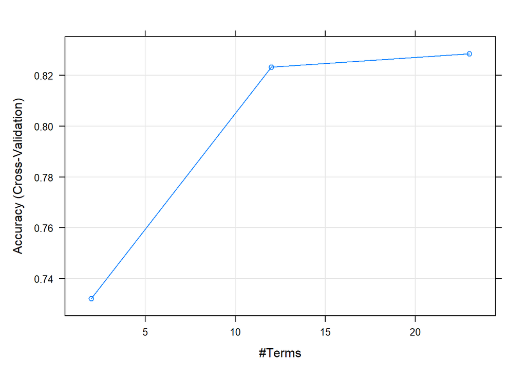

```r
# Plotting the hyper-parameter tuning plot for the second model.

plot(model2)
```

6.4. Plot the comparison of the models in 6.3.

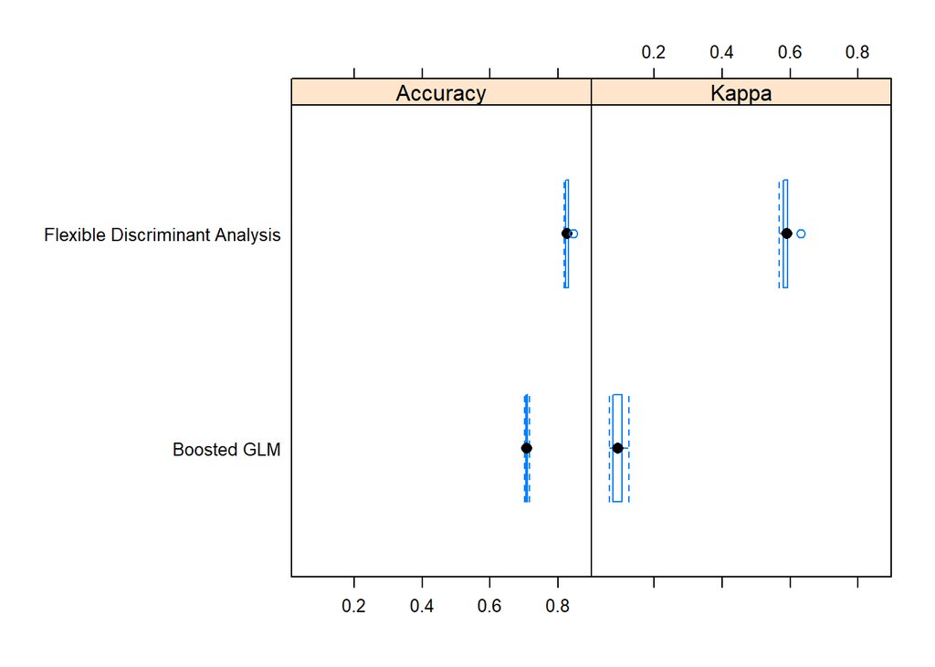

```r
# Plotting the model comparison for statistics such as accuracy and kappa.

comparison <- resamples(list('Boosted GLM' = model1,
'Flexible Discriminant Analysis' = model2))

bwplot(comparison)
```

6.5. What is your final selection for the model? Test the accuracy of your final model on the test data.

```r
# The final selection for the model is the second model which is a flexible discriminant analysis model. This model had both a higher training accuracy and testing accuracy than the first model. The model's training accuracy has been evaluated at ~ 0.8285 and testing accuracy at 0.8245. In addition to having a good accuracy, the model's Kappa value is also relatively high at 0.5843 indicating that this model is reliable. This was done in a prior step, but the code and output are displayed here for reference.

pred <- predict(model2, testDf)

cm2 <- confusionMatrix(data = pred, reference = testDf$target, positive = "long.term")

cm2
```

```
## Confusion Matrix and Statistics
##
##             Reference
## Prediction   long.term short.term
##   long.term      24656       8816
##   short.term     11330      69969
##
##                Accuracy : 0.8245
##                  95% CI : (0.8223, 0.8267)
##     No Information Rate : 0.6865
##     P-Value [Acc > NIR] : < 2.2e-16
##
##                   Kappa : 0.5843
##
##  Mcnemar's Test P-Value : < 2.2e-16
##
##             Sensitivity : 0.6852
##             Specificity : 0.8881
##          Pos Pred Value : 0.7366
##          Neg Pred Value : 0.8606
##              Prevalence : 0.3135
##          Detection Rate : 0.2148
##    Detection Prevalence : 0.2916
##       Balanced Accuracy : 0.7866
##
##        'Positive' Class : long.term
##
```

7. Write a paragraph to summarize the section and give your comments on the results.

After training 2 different models using various methods, the first model has been decided as the final model. This model utilized the method ‘ranger’ along with the tuning parameters ‘mtry’, ‘splitrule’, and ‘min.node.size.’ The model has displayed the best model performance statistics such as testing accuracy and kappa indicating that it is a strong model for predicting the level of total charge. Furthermore, The model’s testing accuracy has been evaluated at 0.8481 and kappa at 0.5785. In comparison, the other model used in this section used the method `pls`. The only tuning parameter for this model was ‘ncomp’ which determined the number of factors. The value of ncomp that resulted in the highest accuracy was ‘ncomp = 5’, but the testing accuracy was still significantly lower than the first model. On the other hand, when the target variable was set `timeAdmitted`, which recorded whether a patient had a longer or shorter stay, two additional models were created. The first model was a boosted generalized linear model with the tuning parameters ‘mstop = 5’ and ‘prune = 1’. The testing accuracy of this model was somewhat low at approximately 0.707, and the low kappa value indicated that this model was not reliable. For the second model, it was created with the ‘method = fda’ meaning that the model uses flexible discriminant analysis. This model contains the tuning parameters ‘nprune’ and ‘degree’. The testing accuracy for the second model has been evaluated at 0.8245, and the Kappa value of 0.5843 indicates that this is a reliable model. Therefore, final model decided was the second model due to better model performance statistics such as testing accuracy and Kappa.